# Actualización sobre mi presencia en la red

José R. Ferrer Paris (@jrfep)

# Publicaciones y citas

He publicado hasta la fecha [16 artículos en revistas arbitradas](http://jrferrerparis.info/homo-faber/publicaciones/) y [más de 70 documentos](http://jrferrerparis.info/homo-faber/otras-contribuciones/) en portales o colecciones electrónicas.

Para una selección de 50 documentos preparé un análisis de impacto usando varios indicadores. En estos documentos acumulo 88 citas según [Google Scholar](https://scholar.google.co.ve/citations?user=A2Thq5UAAAAJ&hl=en) o 61 citas según [Crossref](https://www.crossref.org/) y el score acumulado de impacto según [Altmetric](https://www.altmetric.com/) es 282.45.

En el siguiente gráfico muestro la distribución de citas y *altmetric scores* para estos documentos:

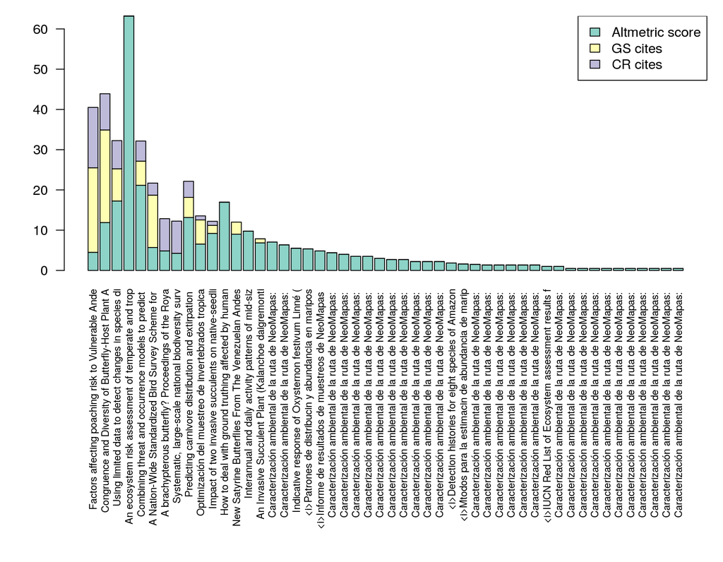

Figura 1: Impacto de publicaciones de JRFeP

# Contribuciones en portales y redes

Soy de una generación casi obsoleta, de ese grupo de personas que aprendió a usar y aprovechar las computadoras ANTES de que se popularizara internet, de aquellos que pasaban horas configurando su entorno local y respaldaban su trabajo en disquettes o CDs, que usaba *pine* para ver su correo en un terminal UNIX y se conectaba a canales *[IRC](https://en.wikipedia.org/wiki/Internet_Relay_Chat)*, ANTES de la nube, ANTES…

Sin embargo, con el paso del tiempo, uno termina convenciendose de que debe aprende también a aprovechar las herramientas nuevas que indudablemente hacen las cosas más fáciles y ayudan a mejorar la productividad.

Una de las grandes ventajas de las herramientas web modernas es que le permiten a los usuarios mostrar su desempeño y actividad, y dejar un testimonio (probablemente mucho más fugaz de lo que pensamos) de nuestras contribuciones a una comunidad local o global.

Aquí pues les dejo una breve instantánea de mis contribuciones a una selección de páginas y proyectos que reflejan parte de mi actividad en la web de los últimos años:

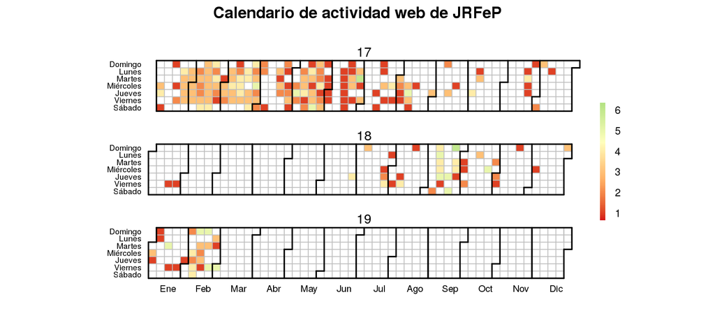

Figura 2: Calendario de actividad en diversos portales web

- Contribuciones a wikipedia en [inglés](https://en.wikipedia.org/wiki/Usuario:Jrfep) y [español](https://es.wikipedia.org/wiki/Usuario:Jrfep)
- Mensajes en twitter de las cuentas jrfep, NeoMapas y Rsaurio
- Entradas de mi blog en WordPress
- Contribuciones a un par de proyectos en [github](https://github.com/jrfep)

Durante este año, espero ir aumentando constantemente mis contribuciones y mostrar aquí como voy progresando.